# Solutions to the Short-Term Economic Impacts of Marine Reserves

Dan Ovando, Dawn Dougherty, Jono Wilson

July 9, 2015

# Cover Letter

Dear Editor,

The extensive debate on when and if no-take marine reserves can benefit fisheries has centered around long-term economic effects. Very little work has considered the economic impacts of reserves over time frames that matter more to communities and decision makers. Our paper, *Solutions to the Short-Term Economic Impacts of Marine Reserves“, builds from the existing literature on marine reserves to advance our understanding of how reserves affect fisheries profits over time, and to what extent design and financial instruments can offset economic losses.

We find that a decade or much more is often needed for a community to see a net economic benefit from implementing a marine reserve, even if the eventual benefits are very large. Careful design of the reserve can help offset early losses, but financial strategies such as improving the value of the catch show much more promise. Our results provide a novel consideration of the ways in which reserves affect fishing communities over the short-term, and show that economic tools may be the future for resolving those losses.

Our paper suggests a framework for assessing and communicating the economic effects of no-take marine reserves on fisheries. The case studies included provide a “best-case scenario” against which to assess the likely fishery impacts of reserves in other locations. Marine reserves can have substantial benefits to conservation and fisheries, but overlooking the short-term economic impacts is both misleading to fishing communities and detrimental to conservation in the long-run. Our goal is for this paper to shift the discussion of marine reserves as fishery management tools towards the challenges and solutions for the short-term economic impacts. Given its integration and advancement on a broad literature, novel findings, and wide scope, we feel that this paper is an ideal candidate for publication in Fish and Fisheries.

Thank you for your consideration,

Dan Ovando

# Abstract

Well-managed fisheries are critical for supporting healthy ocean ecosystems, coastal livelihoods, and food security for millions of people. Many communities lack the resources to implement effective fisheries management. No-take marine reserves are a relatively simple tool to conserve biodiversity and provide fishery benefits. While the biological and long-term economic effects of reserves on fisheries have been well studied, the short-term economic impacts of establishing marine reserves are rarely considered. In this paper we simulate fisheries for six species commonly caught in coastal fisheries in order to demonstrate the time required for a no-take reserve to provide a net improvement in the economic well-being of a fishing community. Our results show that while conservation benefits accrue rapidly, more than a decade is often required to provide net fisheries benefits, even under circumstances favorable for reserves. We explore a suite of strategies for mitigating these short-term economic losses, including flexible reserve designs, loans, and value increases. Our results indicate that reserves may struggle to provide short-term economic benefits to artisnal fisheries, and value increases show the most potential for offsetting these losses. Our findings provide mechanisms for improving the communication and use of no-take marine reserves as tools for fisheries management and conservation.

# Introduction

More than 260 million people across the globe earn their livelihood in fishing related industries (Teh et al. 2014). Fish is a primary source of protein to over one billion people (FAO 2011). Yet the sustainability of the fishing industry and the potential for wild capture fisheries to feed a growing population is dependent on the implementation and enforcement of effective systems of governance and management. No-take marine reserves (hereafter reserves) are areas set off-limits to fishing, and are a widely used tool for protecting fish populations and maintaining ecosystem services to coastal environments. Benefits of marine reserves include the maintenance of spatial population structure of fish stocks (Berkeley *et al.* 2004; White *et al.* 2008; Rassweiler *et al.* 2012), protection of essential fish habitat, increased species diversity and fish biomass (Lester *et al.* 2009), a buffer against changes in environmental conditions (Stefansson and Rosenberg 2005; Costello and Polasky 2008). Reserves can also serve as reference areas to set local management regulations and disentangle the effects of fishing from environmental variability (Wilson *et al.* 2014). Enhanced biological production inside reserves can benefit adjacent fisheries through adult spillover (Roberts and Polunin 1991; Allison *et al.* 1998; McClanahan and Mangi 2008) and larval export ((Cudney-Bueno *et al.* 2009; Pelc *et al.* 2010), especially in situations where the size of the reserve is larger than the adult home range size, and smaller than the scale of larval dispersal (Gerber *et al.* 2003).

In some cases marine reserves can serve as a mechanism for simultaneously achieving conservation outcomes and improving the productivity of fisheries (Hilborn *et al.* 2006; Gaines *et al.* 2010). However, the ability of marine reserves to serve this dual role is dependent on a suite of factors, including the source sink dynamics of the stock, the size of reserve relative to the home range size of the species, the dispersal potential of the species, the geographic extent of the stock, as well as the status of the fishery prior to implementation of reserves (Sanchirico and Wilen 2001; Smith and Wilen 2003; Sanchirico *et al.* 2006; Costello and Polasky 2008; White *et al.* 2008; Rassweiler *et al.* 2012). Moreover, the implementation of marine reserves necessarily reduces the spatial extent of the fishery, often limiting take in prime fishing grounds and concentrating effort into areas where fishing is still allowed (Halpern *et al.* 2004).

The challenges of utilizing reserves as fishery management tools have been well studied (Hilborn *et al.* 2004), However, there is a critical gap in the understanding of economic effects of reserves over time. Nearly all of the published research on the topic has considered the long-term (or equilibrium) economic impacts of implementing a marine reserve. Short-term impacts to fishermen and communities can have profound implications on the financial health and food security of fishing communities. Depending on the time horizon that a community is able or willing to consider, a reserve that provides long-term fishery benefits may in fact cause severe hardship in the short term, thus providing little practical benefit to today’s fishers and decision makers. Such impacts influence local support and buy-in for enforcement policies, trust in management agencies and supporting organizations, and ultimately the sustainability of the fishery itself.

Tradeoffs between the short and long term economic impacts of marine reserves can potentially be mitigated through optimizing reserve design scenarios (Brown *et al.* 2014), including proper siting as well as flexibility in the size and scope of reserve configurations over time. However, such considerations require knowledge of the local oceanography and fishery dynamics that often eludes managers of fisheries for which reserves are being considered. If reserves are to be implemented as conservation tools for fisheries in which resources and capacity to design optimal reserve configurations are lacking, then an alternative consideration must include a means to offset economic losses in the short term

In this paper we develop a spatial bioeconomic simulation model that considers two financial strategies to offset reserve-induced economic losses over the short term: 1) financial loans and 2) increases in the ex-vessel price paid to fishermen. We focus our efforts on simulating a small-scale, semi-artisanal fishery targeting a variety of tropical reef finfish. Small-scale fisheries throughout the developing tropics such as that modeled here are often considered as sites for reserve-based management due to their limited capacity for more involved fishery management practices such as quotas, effort controls and gear restrictions. As such, insights into how to offset short term economic losses of reserve implementation will have profound impacts on achieving the dual objectives of fisheries yield and conservation in situations where the capacity and resources for alternative management regimes are lacking.

We set out to understand feasible mechanisms for offsetting the short term economic losses of implementation of marine reserves. In the following sections, we describe the operating model and the fishery dynamics of our simulated fishery. We then address a series of questions following a line of inquiry centered on the following hypotheses:

1. Short term economic losses from marine reserve implementation are real and are fundamentally shaped by the discount rate applied to a fisher or a fishing community.
2. Flexible reserve designs that allow for expansion or contraction of reserve size can offset economic losses
3. Financial mechanisms such as loans or increases in ex-vessel prices can reduce short term economic losses from marine reserve implementation.

# Methods

## Operating Model

We modeled 6 different finfish species, representing a range of life-history traits of species often targeted by tropical developing country fisheries (Table.1). Our model is single species, age-structured, and is closed to larval and adult emigration and immigration. The spatial configuration of the fishery includes 100 unique patches with wrapped edges connected by larval and adult movement. The model tracks stock numbers, biomass, and fishery yields over time. This structure best represents a small-scale fishing community on an island or isolated stretch of coastline.

Life history values were drawn from stock assessments where possible, in order to help ensure reliable and consistent values (Table.1). The recruitment model (or the functional form of the density dependence relationship) was selected from the possible structures outlined in Babcock & MacCall (2011) using expert judgment. Adult movement (*Range*) is parameterized by defining the number of patches moved by adults in a time step, with 100% indicating total mixing and 0% a completely sedentary species.

The number of fish in patch i at age a at the beginning of year t+1 is

1. $N_{i,a,t+1} = R_{i,t+1}$ if *a = 0*
2. $N_{i,a,t+1} = N_{i,a-1,t}e^{-M-F_{i,t}\upsilon_{a-1}}$ if $1 \leq a < x$
3. $N_{i,a,t+1} = N_{i,x-1,t}e^{-M-F_{i,t}\upsilon_{x-1}} + N_{i,x,t}e^{-M-F_{i,t}\upsilon_{x}}$ if $a = x$

where *R<sub>i,t</sub>*is the recruitment in patch *i* in year *t*, *F<sub>i,t</sub>* is the instantaneous fishing mortality in patch *i* in year *t*, $\upsilon_{a}$ is the selectivity of the fishing gear for a fish at age *a* (which we assume to be 1 for all ages), *M* is the instantaneous natural mortality, and *x* is the maximum age recorded in the model (the plus group). This model assumes that the biological parameters of each species are homogeneous across space and time.

The simulations begin at an unfished equilibrium using a specified unfished initial recruitment in each patch *i*, *R<sub>i,0</sub>* such that

4. $N_{i,a} = R_{i,0}$ if *a = 0*
5. $N_{i,a} = N_{i,a-1}e^{-M}$ if $1 \leq a < x$
6. $N_{i,a} = \frac{N_{i,x-1}e^{-M}}{1-e^{-M}}$ if $a = x$

The average length (*l<sub>a</sub>*) of fish in each age class is calculated using a von Bertalanffy growth equation

7. $l_{a} = L_{inf}(1-e^{-k(t-t_{0})})$

and then converted to average weight (*w<sub>a</sub>*) using:

8. $w_{a}=b_{1}l_{a}^{b_{2}}$

We assume habitat quality to be the same in all patches. Adult movement at each time step among the 100 patches is then calculated using a Gaussian dispersal kernel

9. $p_{i,j}=e^{\frac{-d_{i,j}^{2} }{2\sigma_{A}^{2}}}$

where *p<sub>i,j</sub>* is the proportion of fish moving from area *i* to area *j*, and *d<sub>i,j</sub>* is the distance between area *i* and area *j*. The model parameter $\sigma_{A}$ defines the movement range for the species, and is scaled by the *Range* parameter. We wrap movement in order to remove edge effects. The relative proportions are then normalized so that the total proportion of fish moving from area *i* to any area sum to one. The number of fish in each age group one and older after movement are then

10. $N_{i,a,t} = \sum^{100}_{j=1} N_{j,a,t}p_{i,j}$

To calculate recruitment each year in each patch we use the recruitment models described in Babcock & MacCall (2011), in order to allow the nature of density dependence to vary among species (for example, pre or post settlement density dependence).

## Fishery Dynamics

The catch in each patch at each time step is calculated as

11. $Y_{i,t} = \sum_{a}(N_{i,a,t}e^{-F_{i,t}\upsilon_{a}})$

We assume a closed population of fishers, where the number of fishers does not change with the implementation of a reserve (no emigration or immigration of boats), such that the effort from the reserve area is displaced to the fished area. This is intended to reflect a subsistence style fishery, with few alternative livelihoods besides fishing. We do not however explicitly model fishers or vessels, but rather fishing mortality *F*, in order to reduce model components. Fishing mortality is scaled by the relative commercial biomass,$\bar{B}_{i}$, in each patch where

12. $\bar{B}_{i}= \frac{B_{i}}{\sum_{i}B_{i}}$
13. $F_{i,t}=F_{i,pNTZ}(1+P_{NTZ})\bar{B}_{i,t}$

Where *F<sub>pNTZ</sub>* is the total possible instantaneous fishing pressure in the patch *i* before the implementation of the reserve, and *P<sub>NTZ</sub>* is the fraction of patches that are in a reserve.

## Measuring Economic Impact

We first set out to demonstrate the basic concept that implementation of reserves creates short term economic losses that are of considerable importance, especially when factoring in the future value of money through a discounting term. Net present balance (NPB) is our primary metric of performance to track economic gains and losses. NPB represents the present value of the cumulative yield benefits of a given reserve strategy relative to the status quo, calculated as

14. $NPB_{s} = \sum^{T}_{t=0} \frac{Y_{s,t}-Y_{q}}{(1+r)^{t}}$

for any given species, where *t* is time, *Y* represents fishing yields, *s* is reserve implementation strategy, *q* is the status quo, *r* is the economic discount rate, and *T* is a specified number of years after reserve implementation in which *NPB* is calculated and compared across scenarios and species. We calculate the year at which NPB surpasses zero (increased benefits have compensated for short-term losses).

NPB is an important output, since it reflects the benefits that a community today perceives they will receive over time from a given reserve strategy, relative to the benefits they would have received without the reserve. So a positive NPB implies that the community perceives a net improvement in catches resulting from the reserve, whereas a negative NPB implies a net loss in catches over time resulting from the reserve. Alternatively, the yield balance which is the difference between catches with and without a given reserve in year t, may not be as meaningful to a community. For example, a one ton increase in catches at year ten, relative to the status quo, is of little value if 1,000 tons have been lost in years 1 through 9.

NPB is a function of both the stream of future yields relative to the status quo and the discount rate. A discount rate of 0.05 is the default value in much of the economic literature. However, our thought experiment for this study is the management of an artisnal fishery. While few studies have actually estimated the discount rate for artisanal fishers, those that have report much higher discount rates than 0.05. Johnson & Saunders (2014) and Curtis (2002) found discount rates of artisnal fishermen of ~0.22 (mean) and ~ 0.35 (median), respectively, meaning that the fishermen in those studies value profits today much more than profits tomorrow. For these analyses we chose a discount rate of 0.2 reflective of an artisanal fishery (Johnson and Saunders 2014), which still allows some preference for future benefits by the community.

## Measuring Utility

Reserves often face competing objectives between long-term conservation benefits and short-term economic benefits. This can be empirically illustrated by considering the cumulative biomass of fish in the water over time with a discount rate *r* of 0 (long-term conservation planner, $B_{r_{0}}$) vs. the net present benefits of the reserve over time with a discount rate *r* > 0 (in this case we consider 0.2, $Y_{r_{0.2}}$)). In order to consider the relative utility of a given reserve strategy *s* we assign a weighting parameter $\alpha$ that can take any value from 0 to 1, such that total utility *U* is calculated as

15. $U_{s} = \alpha(\frac{Y_{r_{0.2},s}}{\sum_{s}Y_{r_{0.2},s}}) + (1-\alpha)(\frac{B_{r_{0},s}}{\sum_{s}B_{r_{0},s}})$

This allows us to calculate utility focused solely on discounted fishery benefits ($\alpha$=1), long-term conservation benefits ($\alpha$=0), or any relative weighting in between). “Optimal” reserve policies are found by determining the combination of terminal reserve size, initial reserve size, and slope that maximizes utility *U*.

## Reserve Design

We use the simulation model to examine how the implementation of flexible reserve designs that allow an increase or a reduction in the size of the reserve over time could offset short term economic losses. We explore reserve design scenarios that are defined by a terminal reserve size (% of area in a reserve), initial size (% of the area in a reserve in year 1), and a “slope” (% of run years at which the reserve reaches terminal size). We allow the final size, initial size, and rate at which the reserve reaches its final size to vary. For any scenario a single reserve is applied as a continuous block of cells in the center of the system (alternative configurations such as a reserve on the left or right side of the system do not alter results).

# Results

## Importance of Discounting

Short term economic losses from implementation of reserves are well described (Brown *et al.* 2014) and generally reflect outcomes of our thought experiment described above (Fig 1). However, the importance of understanding how the future value of money will influence the support and buy-in for reserve policies cannot be overstated. The discount rate reflects the degree to which money today is favored over money tomorrow; the higher the rate, the less a community (or individual) values something in the future relative to today.

## Design Solutions to Short-Term Losses

We first explore how the size of the reserve affects the short-term economics of our simulated fisheries. Under this thought experiment, the fishery is assigned a constant reserve size, ranging from 2.5% to 50% of the available habitat. We apply this procedure to each of the 6 species evaluated here, running over a 50 year time horizon, using our default discount rate of 0.2 .

Due to the overfished conditions simulated, any of the reserve sizes tested here provide at least equal to or greater lifetime catches than those that would have occurred without the reserve . Peak improvements in long-term catches occured generally at reserve sizes near 20%. However, it is much more difficult for a reserve to provide positive NPB values to the simulated fisheries. Only the red throat emperor and yellowtail snapper fisheries are capable of providing substantially positive NPB values to the community under any of the evaluated reserve sizes, though at small reserve sizes red grouper and bumphead parrotfish fisheries were able to achieve NPBs of near to or slightly above 0. The time required to achieve a positive NPB was generally greater than 10 years (Fig.3).

We next consider the potential NPB outcomes for our simulated fishing community from allowing the reserve to grow or shrink with time. We set $\alpha$ to 0.9, meaning that 90% of the community’s utility comes from fishery benefits, but some consideration is made for long-term conservation outcomes (this is done to ensure that a reserve of any size is optimal in the future).

Our results show that dynamic designs can improve the economic outcomes of the reserve in all fisheries except those for blacknose shark and silver trevally. This stands in contrast to static reserve designs in which red throat emperor and yellowtail snapper were the only species to experience positive NPB. Under the optimal strategy, yields generally began to exceed status quo yields within 5-10 years. The time to positive NPB was much longer, generally 10 or more years when positive NPB values were possible. we find the optimal strategy for a reserve that is capable of any positive NPB is to start at a larger reserve size and decrease in size over time (Fig.4). Our results contradict previous findings of flexible reserve designs (Brown *et al.* 2014), which suggested short term economic losses could be overcome with growing reserve designs.

## Multispecies Considerations

Many artisanal fisheries are likely to target multiple species at once. To account for this, we consider the economic impacts of a reserve scenario designed around one species but applied to all six of the fish considered here. For each of the six species included here, we find the utility maximizing reserve strategy. We then apply that optimal strategy to each of the other species’ fishery, and assess how detrimental to utility that strategy is when applied to species for which it was not designed.

## Financial Solutions to Short-Term Losses

Flexible reserve design strategies are one means to offset short term economic losses of reserve implementation. We also analyze two potential financial mechanisms for offsetting short-term fishery losses; a loan system and a value-added system. The total relative loss in yields experienced by the fishery for a given scenario *s* is

16. $O_{s} = -\sum^{T}_{t=0} min(0,Y_{s,t}-Y_{q})$

Where *O<sub>s</sub>* is the amount of yield lost relative to the status quo (*sq*) over time period *T*.

### Loans

Under the loan strategy, a non-governmental organization, government, or private investor could provide a community with a loan to offset any initial losses from implementing a reserve, with a goal of being repaid by the future fishery benefits resulting from enhanced fishery productivity. The fishing community requests a loan totaling *O<sub>s</sub>*. The surplus available to pay the loan back over time *T* are equal to

17. $S_{s} = -\sum^{T}_{t=0} max(0,Y_{s,t}-Y_{q})$

Where *S<sub>s</sub>* is the total positive difference in yields (if any) for a given reserve scenario *s*,over what the fishery would have experienced under the status quo.

For a given loan interest rate *i* for a loan of duration *T*, the total loan payments are equal to

18. $C = Tp( \frac{\frac{i}{p}{O}}{1-(1+i)^{-Tp}})$

where *p* is the number of payments per year. Setting the time window of the loan to *T* of 10 years with *p* of 4 payments per year, we then use the *optim* package in *R* (R Core Team 2015) to estimate the highest interest rate *i* (%) that the community could afford in order to pay back a 10-year loan such that *C<sub>s,i</sub> <= S<sub>s</sub>*; meaning that the total loan payments must be less than or equal to the surplus generated by the reserve. The higher the maximum potential interest rate, the more viable the loan is. We break loans apart in to three categories: Interest rates greater than 5% are considered “commercial” (the high rate reflective of the risk in fisheries loans), 1%-5% “social investment” loans, provided by entities that expect a rate of return but may be less concerned with turning a profit, and philanthropy (<1%).

For this experiment, we once again consider a single reserve size applied at once. We find that under these assumptions, loans are not a broadly viable strategy for offsetting the short-term economic losses of the reserve. Loans at any rates above philanthropic levels are viable only for red throat emperor, yellowtail snapper, and red grouper fisheries. The red throat emperor fishery could pay back a commerical loan, even at very high rates, for any of the evaluated reserve sizes. The yellowtail snapper fishery could afford commercial or social investment loans for reserves less than 20% in size, while a social investment loan is possible for the red grouper fishery but only for a very small reserve. For any other reserve sizes or fisheries, there are not enough yield benefits within a ten year window to pay back any loan above a philanthropic rate (Fig.6).

### Value Increases

The value increase experiment asks by how much the value of the fishery’s catch would have to increase to completely offset the worst yield losses induced by the reserve in any given year. By extension then, that same value increase would more than offset any lesser losses occurring in other years. We implicitly assume a status quo value of $1 per unit weight (though this is an arbitrary choice that does not influence the results). We then ask by what percent the value of the catch caught under a given scenario *s* would have to increase in order to completely offset the greatest loss of yields seen across all years

19. $P_{s} = 100(\frac{Y_{q}}{Y_{q}+min(Y_{s}-Y_{q})}-1))$

# Discussion

We propose a metric (NPB) to measure cumulative economic gains after the implementation of a reserve. We then use this metric to compare three mechanisms for offsetting the short term economic losses of implementing a marine reserve, including: flexible reserve design, loans and value increases. We find that, while all three mechanisms can give long term benefits to fisheries, only value increases to the ex-vessel price paid to fishermen were consistently able to offset short-term economic losses to fishing. Even optimally designed reserves struggled to provide net economic benefits within a decade. While loans were viable in some special cases, most instances showed that the interest rate a community could afford to pay on a 10-year loan was too low to be viable for anything but a philanthropy backed loan.

Our results demonstrate a need for a different approach and communication strategy for designing marine reserves for fisheries and community benefits. Using long term changes in yield as a benchmark for fishery benefits ignores the local discount rate and short term loss in yield to the community. Instead, practitioners should use NPB or similar metrics to clearly communicate the expected short term losses and timing to benefits resulting from a proposed reserve. With this approach, reserve design strategies should shift from only considering sizing and spacing details, and additionally work on exploring linkages between affected fisheries and the seafood industry. Such linkages could allow arrangements with seafood suppliers and fishing communities that provide a price premium to fishing communities who choose to implement and enforce no-take marine reserves for conservation purposes. Alternatively, benefits from tourism could be used to help offset short-term fishery losses (Sala *et al.* 2013).

We make several assumptions in the parameterization and setup of the operating model. While each of these assumptions impact our results, we believe that on the whole our assumptions give the best possible ability for a reserve to provide economic benefits. These assumptions include: (1) starting with an overfished population at 15% of its unfished stock size; (2) modeling a closed fish population; (3) modeling a closed community, where all economic benefits are captured by the local fishing community; (4) modeling complete selectivity of all sizes by the fishery; and (5) allowing no capacity for additional fishery management practices. Using our assumptions, our results show that even when substantial long-term benefits are predicted to result from a reserve, it may take over a decade for the reserve to result in a net gain in fishing yields for the community. While this may be entirely acceptable to some communities, the discount rates reported by Johnson & Saunders (2014) and Curtis (2002) suggest that the magnitude of these eventual benefits would not be sufficient to offset the short-term losses required to achieve the gains. Presenting the evolution of net benefits over time as we have done allows researchers and decision makers to confront the potential economic impacts of a reserve, and determine whether a reserve of a particular size and design is likely to provide meaningful net benefits to a community.

Our results demonstrate the need for tighter linkages between government and non-government advocates for marine reserves and the seafood supply chain and independent seafood certification and labeling organizations. It is imperative that those engaged in the design and implementation of reserves carefully consider and communicate the short-term impacts of reserves on the economic well-being of affected fisheries. It is misleading to tell a community that a reserve will provide fishery benefits, but neglect to point out that those benefits may not accrue for some time. In addition, support and enforcement of a reserve may quickly dissipate if a reserve does not begin to provide net economic benefits to a community on the time scale fishermen were expecting. The NPB framework presented here is an important tool for assessing the short-term economic impacts of a reserve. Discussing the timing and magnitude of benefits stemming from reserves allows stakeholders to directly confront the challenges, and consider what solutions may be on the table given their circumstances. Our results indicate that rather than focusing on eliminating short-term losses through careful design, or counting on future benefits to finance fishery improvement loans, more potential lies in helping communities increase the value of their catch to offset reserve induced losses.

# Acknowledgements

We are grateful for assistance and guidance from Lennon Thomas, Sarah Lester, Chris Costello, and Steve Gaines. DO was supported by a grant from the Waitt Foundation and the Daniel and Dianne Vapneck Fisheries Management Fellowship.

# Tables

Life history values used. m is natural mortality, Linf (in mm), k, and t0 are the Von Bertalanffy growth parameters, Age/Len Ma50 are age (years) or lengths (mm) at 50% maturity, h is steepness, and the DD value corresponds with the form of density dependence from Babcock & MacCall 2011. Values with * were assumed

| Species | Sci.Name | Range | m | k | Linf | t0 | Age50 | Len50 | h | DD | Source |
| --- | --- | --- | --- | --- | --- | --- | --- | --- | --- | --- | --- |
| Yellowtail Snapper | Ocyurus chrysurus | 20%* | 0.19 | 0.13 | 618.0 | -3.13 | 1.7 | 232.4 | 0.70 | III* | Hop et al. 2012 |
| Red Grouper | Epinephelus morio | 20%* | 0.14 | 0.16 | 854.0 | -0.19 | 3.0 | 341.0 | 0.84 | II* | SEDAR 2009 |
| Silver Trevally | Psedudocaranx dentex | 60%* | 0.10 | 0.05 | 631.6 | -0.65 | NA | 190.0 | 0.75 | III* | Rowling & Raines 2000; Tuck 2007 |
| Blacknose Shark | Carcharhinus acronotus | 40%* | 0.23 | 0.32 | 1012.0 | -1.70 | 4.5 | NA | 0.35 | I* | SEDAR 2011 |
| Bumphead Parrotfish | Bolbometopon muricatum | 20%* | 0.28 | 0.12 | 1144.5 | 0.00 | 8.0 | 550.0 | 0.70 | II* | Kobayashi et al. 2011 |
| Red Throat Emperor | Lethrinus miniatus | 40%* | 0.51 | 0.37 | 459.1 | -0.36 | 2.0 | 280.0 | 0.70 | III* | Leigh et al. 2006 |

# Figures

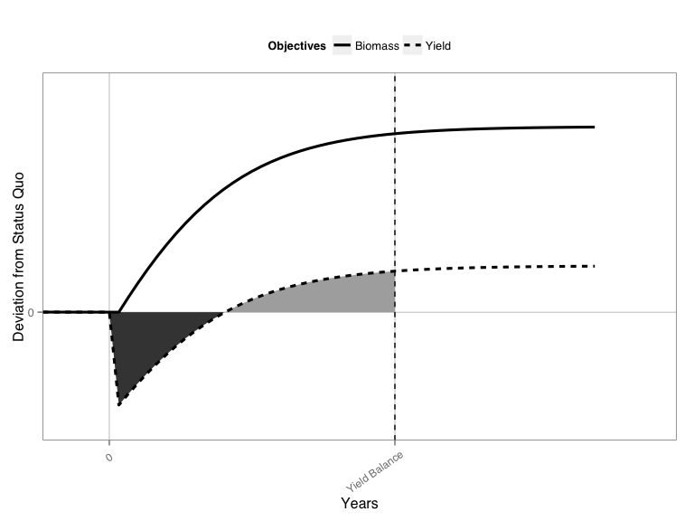

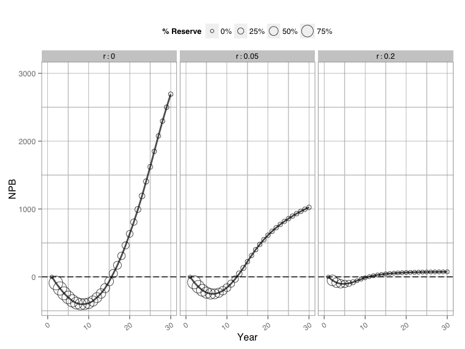

Example NPB trajectories under the optimal reserve scenario under different discount rates (r) for yellowtail snapper. Size of circles represents % of fishery in a reserve. Reserve is implemented in year 1

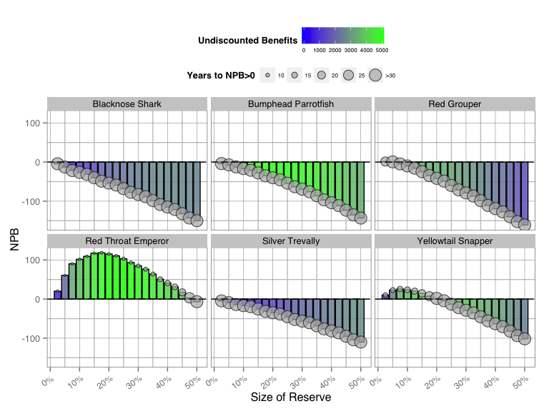

NPB (r=0.2, alpha = 1), across a range of possible reserve sizes for each fishery. Color represents the change in cumulative yields over the cumulative yields that would have occured without the reserve. Size of circles represents the number of years until NPB is greater than or equal to 0

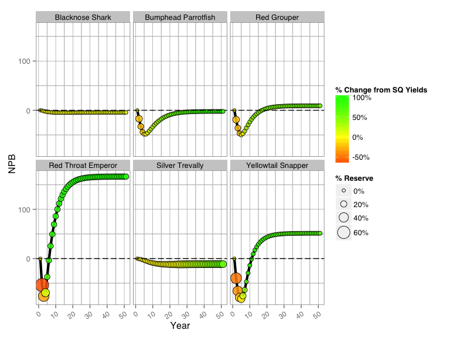

NPB (r=0.2,alpha = 0.9) trajectories under optimal reserve scenarios. Size of circle represents % of the fishery in a reserve. The color represents the yield surplus in a given year over the yield that would have occured without the reserve. Reserve is implemented in year 1

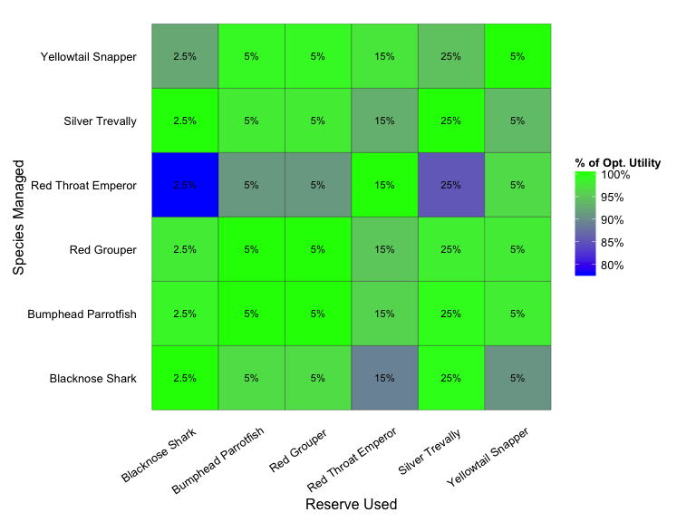

Comparison of utility of each fishery using the optimal reserve for each other fishery. Text shows terminal reserve size

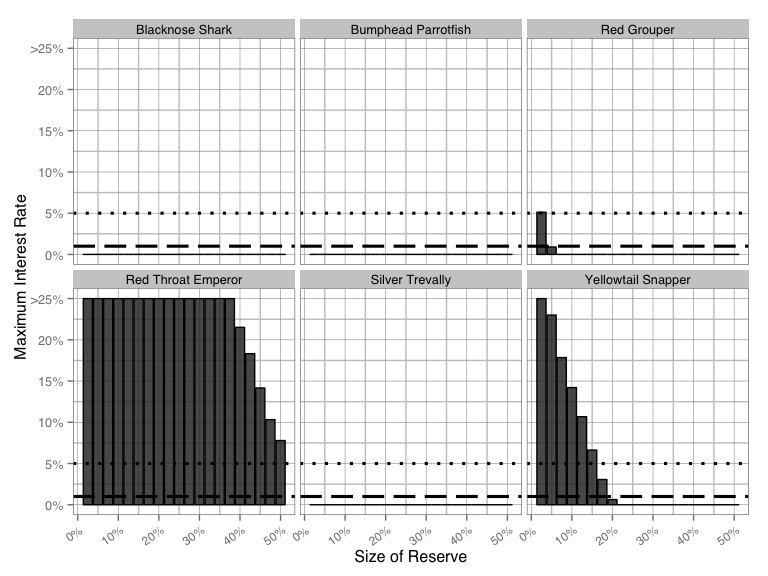

Maximum % interest rate payable by a fishery for each species across a range of reserve sizes. Dashed line indicates break between philanthropic (<1%) and social investment (1%-5%) loans, above dotted line are commercial loans (>5%)

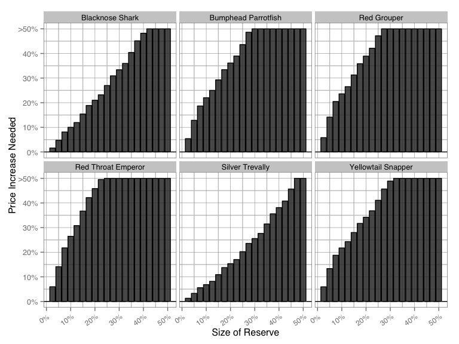

% Price increase required by a fishery to offset the greatest yield loss experienced, accross a range of terminal reserve sizes

Allison, G.W., Lubchenco, J. and Carr, M.H. (1998) Marine reserves are necessary but not sufficient for marine conservation. *Ecological Applications* **8**, S79–S92.

Babcock, E.A. and MacCall, A.D. (2011) How useful is the ratio of fish density outside versus inside no-take marine reserves as a metric for fishery management control rules? *Canadian journal of fisheries and aquatic sciences* **68**, 343–359.

Berkeley, S.A., Hixon, M.A., Larson, R.J. and Love, M.S. (2004) Fisheries sustainability via protection of age structure and spatial distribution of fish populations. *fisheries* **29**, 23–32.

Brown, C.J., Abdullah, S. and Mumby, P.J. (2014) Minimizing the short-term impacts of marine reserves on fisheries while meeting long-term goals for recovery. *Conservation Letters*, n/a–n/a.

Costello, C. and Polasky, S. (2008) Optimal harvesting of stochastic spatial resources. *Journal of Environmental Economics and Management* **56**, 1–18.

Cudney-Bueno, R., Lavín, M.F., Marinone, S.G., Raimondi, P.T. and Shaw, W.W. (2009) Rapid effects of marine reserves via larval dispersal. *PLoS ONE* **4**, e4140.

Curtis, J.A. (2002) Estimates of fishermen’s personal discount rate. *Applied Economics Letters* **9**, 775–778.

FAO (2011) *Review of the state of world marine fishery resources*, (FAO fisheries and aquaculture technical paper 569). Food; Agriculture Organization of the United Nations, Rome, Italy.

Gaines, S.D., White, C., Carr, M.H. and Palumbi, S.R. (2010) Designing marine reserve networks for both conservation and fisheries management. *Proceedings of the National Academy of Sciences* **107**, 18286–18293.

Gerber, L.R., Botsford, L.W., Hastings, A., Possingham, H.P., Gaines, S.D., Palumbi, S.R. and Andelman, S. (2003) Population models for marine reserve design: A retrospective and prospective synthesis. *Ecological Applications* **13**, 47–64.

Halpern, B.S., Gaines, S.D. and Warner, R.R. (2004) Confounding effects of the export of production and the displacement of fishing effort from marine reserves. *Ecological Applications* **14**, 1248–1256.

Hilborn, R., Micheli, F. and De Leo, G.A. (2006) Integrating marine protected areas with catch regulation. *Canadian Journal of Fisheries and Aquatic Sciences* **63**, 642–649.

Hilborn, R., Stokes, K., Maguire, J.-J., et al. (2004) When can marine reserves improve fisheries management? *Ocean & Coastal Management* **47**, 197–205.

Johnson, A.E. and Saunders, D.K. (2014) Time preferences and the management of coral reef fisheries. *Ecological Economics* **100**, 130–139.

Kobayashi, D., Friedlander, A., Grimes, C., Nichols, R. and Zgliczynski, B. (2011) Bumphead parrotfish (bolbometopon muricatum) status review. NOAA-TM-NMFS-PIFSC-26. U.S. Department of Commerce.

Leigh, G.M., Williams, A.J., Begg, G.A., Gribble, N.A. and Whybird, O.J. (2006) Stock asessment of the queensland east coast red throat emperor (lethrinus miniatus) fishery. The State of Queensland, Department of Primary Industries; Fisheries, Queensland, Australia.

Lester, S., Halpern, B., Grorud-Colvert, K., et al. (2009) Biological effects within no-take marine reserves: A global synthesis. *Marine Ecology Progress Series* **384**, 33–46.

McClanahan, T.R. and Mangi, S. (2008) Spillover of exploitable fishes from a marine park and its effect on the adjacent fishery.

O’Hop, J., Murphy, M. and Chagaris, D. (2012) The 2012 stock assessment report for yellowtail snapper in the south atlantic and gulf of mexico. Fish; Wildlife Conservation Commission, St. Petersburg, Florida.

Pelc, R.A., Warner, R.R., Gaines, S.D. and Paris, C.B. (2010) Detecting larval export from marine reserves. *Proceedings of the National Academy of Sciences* **107**, 18266–18271.

R Core Team (2015) R: A language and environment for statistical computing.

Rassweiler, A., Costello, C. and Siegel, D.A. (2012) Marine protected areas and the value of spatially optimized fishery management. *Proceedings of the National Academy of Sciences* **109**, 11884–11889.

Roberts, C.M. and Polunin, N.V.C. (1991) Are marine reserves effective in management of reef fisheries? *Reviews in Fish Biology and Fisheries* **1**, 65–91.

Rowling, K. and Raines, L. (2000) Description of the biology and an assessment of the fishery for silver trevally pseudocaranx dentex off new south wales. NSW Fisheries Research Institute.

Sala, E., Costello, C., Dougherty, D., et al. (2013) A general business model for marine reserves. *PLoS ONE* **8**, e58799.

Sanchirico, J.N. and Wilen, J.E. (2001) A bioeconomic model of marine reserve creation. *Journal of Environmental Economics and Management* **42**, 257–276.

Sanchirico, J.N., Malvadkar, U., Hastings, A. and Wilen, J.E. (2006) When are no-take zones an economically optimal fishery management strategy? *Ecological Applications* **16**, 1643–1659.

SEDAR (2011) HMS gulf of mexico blacknose shark. 21. Southeast Data, Assessment & Review.

SEDAR (2009) Stock assessment of red grouper in the gulf of mexico - SEDAR update assessment. Miami, FL.

Smith, M.D. and Wilen, J.E. (2003) Economic impacts of marine reserves: The importance of spatial behavior. *Journal of Environmental Economics and Management* **46**, 183–206.

Stefansson, G. and Rosenberg, A.A. (2005) Combining control measures for more effective management of fisheries under uncertainty: Quotas, effort limitation and protected areas. *Philosophical Transactions of the Royal Society B: Biological Sciences* **360**, 133–146.

White, C., Kendall, B.E., Gaines, S., Siegel, D.A. and Costello, C. (2008) Marine reserve effects on fishery profit. *Ecology Letters* **11**, 370–379.

Wilson, J.R., Valencia, S.R., Kay, M.C. and Lenihan, H.S. (2014) Integration of no-take marine reserves in the assessment of data-limited fisheries. *Conservation Letters* **7**, 451–458.